# Introduction to R-INLA and INLAjoint

### The predict function

The `predict()` function turns the fitted model into a dynamic tool for patient-specific predictions. It handles the integration over random effects automatically.

Let’s create a new dataset for the first 6 patients to predict their future profiles.

```r
NewData <- pbc2[pbc2$id %in% 1:6, c("id", "drug", "year", "SGOT", "platelets")];NewData
```

```
##    id      drug      year  SGOT platelets
## 1   1 D-penicil 0.0000000 138.0       190
## 2   1 D-penicil 0.5256817   6.2       183
## 3   2 D-penicil 0.0000000 113.5       221
## 4   2 D-penicil 0.4983025 139.5       188
## 5   2 D-penicil 0.9993429 144.2       161
## 6   2 D-penicil 2.1027270 144.2       122
## 7   2 D-penicil 4.9008871 131.8       135
## 8   2 D-penicil 5.8892783 131.8       100
## 9   2 D-penicil 6.8858833 145.7       103
## 10  2 D-penicil 7.8907020 119.0       113
## 11  2 D-penicil 8.8325485  88.0       100
## 12  3 D-penicil 0.0000000  96.1       151
## 13  3 D-penicil 0.4818749  69.8       160
## 14  3 D-penicil 0.9966050  57.4       107
```

[output cut: 20 more lines]

We predict up to year 14. We apply the inverse link function to get predictions on the scale of the observed data and we assume patients were at risk of the event starting at year 1.

```r
P <- predict(IJ, NewData, horizon = 9:14, id = "id",
             survival = TRUE, inv.link = TRUE, Csurv = 1)
```

We can plot the predicted longitudinal counts for platelets:

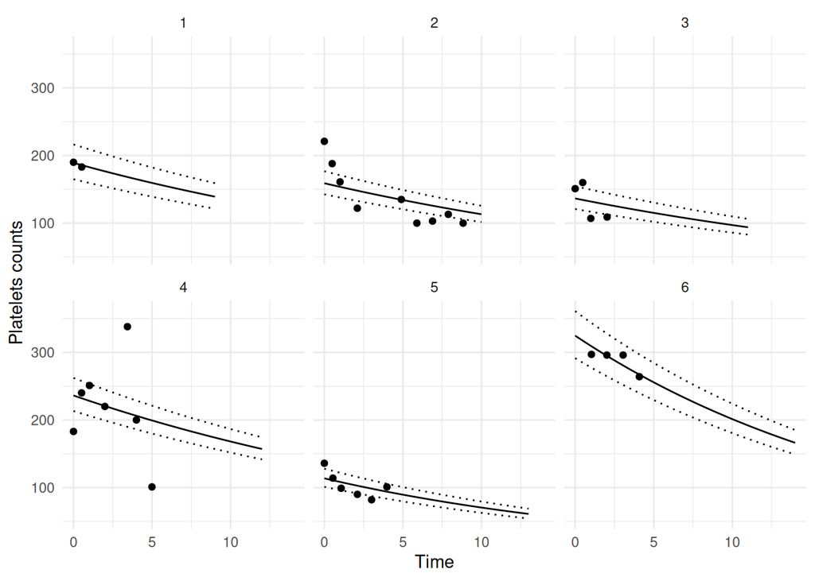

```r
library(ggplot2)
ggplot(P$PredL[P$PredL$Outcome == "platelets", ], aes(x = year, y = quant0.5)) +
  facet_wrap(~id) +
  geom_line() + xlab("Time") + ylab("Platelets counts") +
  geom_line(aes(y = quant0.025), linetype = "dotted") +
  geom_line(aes(y = quant0.975), linetype = "dotted") +
  geom_point(data = NewData, aes(x = year, y = platelets)) +
  theme_minimal() + theme(legend.position = "bottom")
```

We can also plot their dynamically updated survival probabilities:

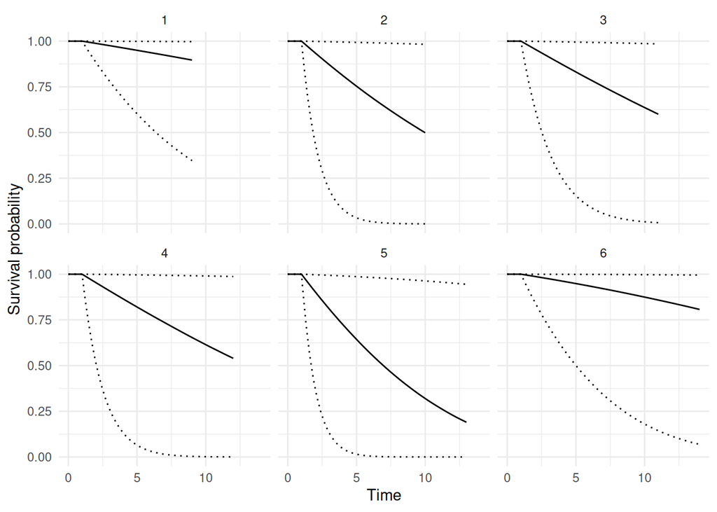

```r
ggplot(P$PredS, aes(x = year, y = Surv_quant0.5)) +
  facet_wrap(~id) +
  geom_line() + xlab("Time") + ylab("Survival probability") +
  geom_line(aes(y = Surv_quant0.025), linetype = "dotted") +
  geom_line(aes(y = Surv_quant0.975), linetype = "dotted") +
  theme_minimal() + theme(legend.position = "bottom")
```

Now that we understand the software mechanics and how to extract information, we can introduce survival analysis.